# Amazon ML Challenge 2026 — Business Entity Resolution

## Full Exploratory Data Analysis

**Task:** for each Source 1 business record, find all Source 2/3 records describing the same real-world business. Scored by **macro-averaged F₀.₅** (precision weighted 2× over recall).

### A note on how this EDA is structured

The raw dataset has **four columns, all strings, and no numeric columns at all**. Standard EDA machinery — `describe()`, skewness, kurtosis, IQR outliers, Q-Q plots, Pearson correlation — requires numeric input, so it cannot be run on the raw tables.

But an entity-resolution pipeline *does* have a numeric matrix: the **pair feature matrix**. Each row is a (Source 1 record, candidate record) pair, the features are similarity measures, and the target is binary `is_match`. That matrix is what a model actually trains on, so profiling it before modelling is the correct application of the checklist.

This notebook therefore runs in two passes:

- **Part I** — raw table profiling: structure, quality, cardinality, categoricals (sections 1–3, 11, 21–23)
- **Part II** — pair-matrix profiling: statistics, distribution, outliers, correlation, target analysis, feature-vs-target (sections 4–10, 12–19)

Section 20 (time series) has no input — the dataset contains no temporal column.

```python
import pandas as pd, numpy as np, matplotlib.pyplot as plt, seaborn as sns
import scipy.stats as stats, warnings, unicodedata, re
warnings.filterwarnings('ignore')
sns.set_theme(style='whitegrid', palette='deep')
plt.rcParams.update({'figure.dpi':110,'figure.figsize':(11,4.5),'axes.titleweight':'bold'})
D = '/home/yash/Downloads/Amazon-ML-dataset/student_resource/dataset/'
FIG = '/home/yash/dev/clg/amlc-2026/eda/figures/'
import os; os.makedirs(FIG, exist_ok=True)
def save(name): plt.tight_layout(); plt.savefig(FIG+name, bbox_inches='tight'); plt.show()
print('ready')
```

```
ready
```

# PART I — Raw tables

## 1. Dataset structure

```python
files = {'train_source1':'train/train_source1.tsv','train_source2':'train/train_source2.tsv',
         'train_source3':'train/train_source3.tsv','train_ground_truth':'train/train_ground_truth.tsv',
         'test_source1':'test/test_source1.tsv','test_source2':'test/test_source2.tsv',
         'test_source3':'test/test_source3.tsv'}
rows = []
for k,v in files.items():
    with open(D+v, encoding='utf-8') as f:
        hdr = f.readline().rstrip('\n').split('\t')
        n = sum(1 for _ in f)
    rows.append({'file':k,'rows':n,'cols':len(hdr),'columns':', '.join(hdr),
                 'size_MB':round(os.path.getsize(D+v)/1e6,1)})
structure = pd.DataFrame(rows)
display(structure)
print(f"TOTAL records: {structure['rows'].sum():,}   TOTAL size: {structure['size_MB'].sum():.0f} MB")
```

|  | file | rows | cols | columns | size_MB |
| --- | --- | --- | --- | --- | --- |
| 0 | train_source1 | 2206821 | 4 | entity_id, business_name, business_address, co... | 210.1 |
| 1 | train_source2 | 5034616 | 4 | entity_id, business_name, business_address, co... | 489.3 |
| 2 | train_source3 | 5285603 | 4 | entity_id, business_name, business_address, co... | 503.7 |
| 3 | train_ground_truth | 2206821 | 2 | source1_entity_id, matched_entity_ids | 127.0 |
| 4 | test_source1 | 1732544 | 4 | entity_id, business_name, business_address, co... | 175.0 |
| 5 | test_source2 | 4887273 | 4 | entity_id, business_name, business_address, co... | 509.5 |
| 6 | test_source3 | 5082316 | 4 | entity_id, business_name, business_address, co... | 506.0 |

```
TOTAL records: 26,435,994   TOTAL size: 2521 MB
```

```python
# a real sample of each source — note the noise patterns
s1 = pd.read_csv(D+'train/train_source1.tsv', sep='\t', nrows=200000)
print('dtypes:'); print(s1.dtypes); print()
print(f'grain: one row = one business record. shape={s1.shape}')
display(s1.head(8))
```

```
dtypes:
entity_id           str
business_name       str
business_address    str
country             str
dtype: object

grain: one row = one business record. shape=(200000, 4)
```

|  | entity_id | business_name | business_address | country |
| --- | --- | --- | --- | --- |
| 0 | S1-925783039 | Orelee's Barbershop | 1795 Westchester Drive, High Point, NC | US |
| 1 | S1-773889195 | Prime Money | 17560 Ellis Road, Tahlequah, OK | US |
| 2 | S1-377745466 | B+ Retail Inc | 1712 Montebello Avenue, Phoenix, AZ | US |
| 3 | S1-133037285 | Christ Chapel | 2100 Cameron Drive, Unit APARTMENT G, Dundalk, MD | US |
| 4 | S1-755362802 | Prabhav Business Center | 797, Lake Town Block A, Kolkata, Howrah, West ... | India |
| 5 | S1-851869949 | Custom Wealth Services LLC | OH, Columbus, 5559 Orville Avenue | US |
| 6 | S1-785847572 | Consulting Nyasa Nursing Private Limited | 2505, Tower 1, Oakwood, Runwal Greens, Mulund ... | India |
| 7 | S1-27541239 | Nexus Anchor Rain | 1111 Church Street, Unit 2007, Nashville, TN | US |

**Observation.** Every column is `object` (string). There is no numeric, boolean or datetime column anywhere in the dataset. This is the structural fact that shapes the rest of this EDA.

## 2. Data quality — missing values

```python
import csv
csv.field_size_limit(10**9)
def quality(path, ncol=4):
    empt = np.zeros(ncol, dtype=np.int64); n=0; bad=0
    with open(D+path, encoding='utf-8', newline='') as f:
        r = csv.reader(f, delimiter='\t'); hdr = next(r)
        for row in r:
            if len(row)!=ncol: bad+=1; continue
            n+=1
            for i in range(ncol):
                if not row[i].strip(): empt[i]+=1
    return hdr, n, empt, bad
qrows=[]
for name,p in [('train_source1','train/train_source1.tsv'),('train_source2','train/train_source2.tsv'),
               ('train_source3','train/train_source3.tsv'),('test_source1','test/test_source1.tsv'),
               ('test_source2','test/test_source2.tsv'),('test_source3','test/test_source3.tsv')]:
    hdr,n,e,bad = quality(p)
    for i,c in enumerate(hdr):
        qrows.append({'file':name,'column':c,'missing':int(e[i]),'missing_pct':100*e[i]/n})
    qrows.append({'file':name,'column':'__malformed_rows__','missing':bad,'missing_pct':100*bad/max(n,1)})
miss = pd.DataFrame(qrows)
display(miss.pivot(index='column', columns='file', values='missing_pct').round(3))
```

| file column | test_source1 | test_source2 | test_source3 | train_source1 | train_source2 | train_source3 |
| --- | --- | --- | --- | --- | --- | --- |
| __malformed_rows__ | 0.0 | 0.000 | 0.000 | 0.0 | 0.000 | 0.000 |
| business_address | 0.0 | 2.648 | 2.678 | 0.0 | 3.356 | 3.328 |
| business_name | 0.0 | 0.000 | 0.000 | 0.0 | 0.000 | 0.000 |
| country | 0.0 | 0.000 | 0.000 | 0.0 | 0.000 | 0.000 |
| entity_id | 0.0 | 0.000 | 0.000 | 0.0 | 0.000 | 0.000 |

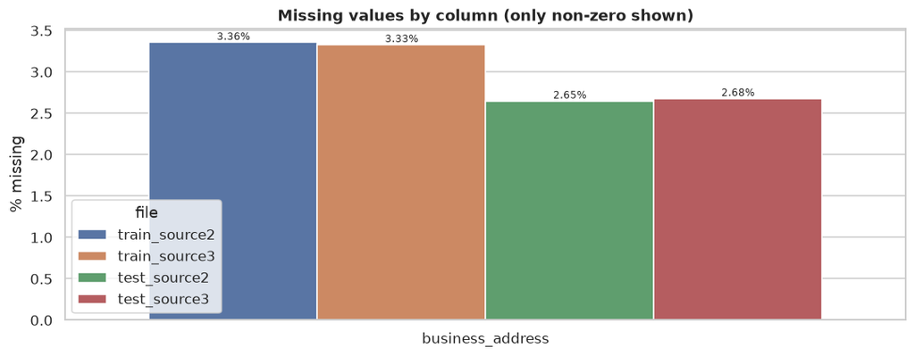

```
Every other column across all 6 files is 100% populated.
```

```python
piv = miss[miss.missing_pct>0]
plt.figure(figsize=(10,4))
ax = sns.barplot(data=piv, x='column', y='missing_pct', hue='file')
ax.set_title('Missing values by column (only non-zero shown)')
ax.set_ylabel('% missing'); ax.set_xlabel('')
for c in ax.containers: ax.bar_label(c, fmt='%.2f%%', fontsize=8)
save('01_missing_values.png')
print('Every other column across all 6 files is 100% populated.')
```

**Finding.** The dataset is exceptionally clean: no nulls anywhere except `business_address` (~3.3% train, 2.65% test), no malformed rows, no ragged fields. A missingness *heatmap* is not informative here — with only one sparse column there is no co-missingness pattern to see.

The ~3.3% empty addresses matter operationally: those records can only ever be matched on name.

## 3. Duplicates

```python
def dup_report(path, ncol=4):
    ids=set(); dup_id=0; seen=set(); dup_full=0; n=0
    with open(D+path, encoding='utf-8', newline='') as f:
        r=csv.reader(f,delimiter='\t'); next(r)
        for row in r:
            if len(row)!=ncol: continue
            n+=1
            if row[0] in ids: dup_id+=1
            else: ids.add(row[0])
            k=(row[1],row[2],row[3])
            if k in seen: dup_full+=1
            else: seen.add(k)
    return n, dup_id, dup_full
out=[]
for name,p in [('train_source1','train/train_source1.tsv'),('train_source2','train/train_source2.tsv'),
               ('train_source3','train/train_source3.tsv')]:
    n,di,df_ = dup_report(p)
    out.append({'file':name,'rows':n,'dup_entity_id':di,'dup_content_(name+addr+country)':df_,
                'dup_content_pct':round(100*df_/n,3)})
display(pd.DataFrame(out))
```

|  | file | rows | dup_entity_id | dup_content_(name+addr+country) | dup_content_pct |
| --- | --- | --- | --- | --- | --- |
| 0 | train_source1 | 2206821 | 0 | 0 | 0.000 |
| 1 | train_source2 | 5034616 | 0 | 25873 | 0.514 |
| 2 | train_source3 | 5285603 | 0 | 18860 | 0.357 |

**Finding.** Zero duplicate `entity_id` anywhere — the key is clean. Content-level duplicates (identical name+address+country) do occur in S2/S3 and are *expected*: they are genuinely distinct records that happen to be identical after the fact. They are **not** errors and must not be dropped, because each carries its own id that the submission has to reference.

## 11 & 21. Categorical features and cardinality

```python
def catprofile(path, ncol=4):
    from collections import Counter
    cty=Counter(); nm=Counter(); ad=Counter(); n=0
    with open(D+path, encoding='utf-8', newline='') as f:
        r=csv.reader(f,delimiter='\t'); next(r)
        for row in r:
            if len(row)!=ncol: continue
            n+=1; cty[row[3]]+=1; nm[row[1]]+=1; ad[row[2]]+=1
    return n, cty, len(nm), len(ad)
card=[]
for name,p in [('train_source1','train/train_source1.tsv'),('train_source2','train/train_source2.tsv'),
               ('train_source3','train/train_source3.tsv'),('test_source1','test/test_source1.tsv'),
               ('test_source2','test/test_source2.tsv'),('test_source3','test/test_source3.tsv')]:
    n,cty,un,ua = catprofile(p)
    card.append({'file':name,'rows':n,'nunique_country':len(cty),'nunique_name':un,
                 'nunique_address':ua,'name_uniq_ratio':round(un/n,3),'countries':dict(cty)})
cd = pd.DataFrame(card); display(cd[['file','rows','nunique_country','nunique_name','nunique_address','name_uniq_ratio']])
for r in card: print(r['file'], '->', r['countries'])
```

|  | file | rows | nunique_country | nunique_name | nunique_address | name_uniq_ratio |
| --- | --- | --- | --- | --- | --- | --- |
| 0 | train_source1 | 2206821 | 2 | 1539229 | 2130606 | 0.697 |
| 1 | train_source2 | 5034616 | 2 | 4402009 | 4337262 | 0.874 |
| 2 | train_source3 | 5285603 | 2 | 4651609 | 4632765 | 0.880 |
| 3 | test_source1 | 1732544 | 3 | 1238867 | 1677483 | 0.715 |
| 4 | test_source2 | 4887273 | 3 | 4311041 | 4224784 | 0.882 |
| 5 | test_source3 | 5082316 | 3 | 4521929 | 4456436 | 0.890 |

```
train_source1 -> {'US': 1323633, 'India': 883188}
train_source2 -> {'India': 2017799, 'US': 3016817}
train_source3 -> {'US': 3170056, 'India': 2115547}
test_source1 -> {'US': 663106, 'France': 259452, 'India': 809986}
test_source2 -> {'India': 2312565, 'France': 703378, 'US': 1871330}
test_source3 -> {'India': 2405000, 'France': 731615, 'US': 1945701}
```

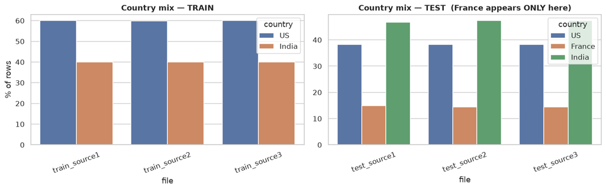

```python
ctab=[]
for r in card:
    for k,v in r['countries'].items(): ctab.append({'file':r['file'],'country':k,'n':v,'pct':100*v/r['rows']})
ct=pd.DataFrame(ctab)
fig,axes=plt.subplots(1,2,figsize=(13,4.2))
sns.barplot(data=ct[ct.file.str.startswith('train')],x='file',y='pct',hue='country',ax=axes[0])
axes[0].set_title('Country mix — TRAIN'); axes[0].set_ylabel('% of rows'); axes[0].tick_params(axis='x',rotation=20)
sns.barplot(data=ct[ct.file.str.startswith('test')],x='file',y='pct',hue='country',ax=axes[1])
axes[1].set_title('Country mix — TEST  (France appears ONLY here)'); axes[1].set_ylabel(''); axes[1].tick_params(axis='x',rotation=20)
save('02_country_mix.png')
```

### FINDING — distribution shift: France

France is **~15% of the test Source 1 set and completely absent from training**. Any feature that learns country-specific patterns contributes nothing on a sixth of the test data.

## 22. Constant and near-constant features

```python
nc=[]
for r in card:
    dom = max(r['countries'].values())/r['rows']
    nc.append({'file':r['file'],'column':'country','n_unique':len(r['countries']),
               'dominant_pct':round(100*dom,2),'near_constant':dom>0.95})
display(pd.DataFrame(nc))
print('No raw column is constant or near-constant. (A constant feature IS found in Part II.)')
```

|  | file | column | n_unique | dominant_pct | near_constant |
| --- | --- | --- | --- | --- | --- |
| 0 | train_source1 | country | 2 | 59.98 | False |
| 1 | train_source2 | country | 2 | 59.92 | False |
| 2 | train_source3 | country | 2 | 59.98 | False |
| 3 | test_source1 | country | 3 | 46.75 | False |
| 4 | test_source2 | country | 3 | 47.32 | False |
| 5 | test_source3 | country | 3 | 47.32 | False |

```
No raw column is constant or near-constant. (A constant feature IS found in Part II.)
```

## 23. Data validity / logical errors

```python
DEVA=re.compile(r'[ऀ-ॿ]'); CTRL=re.compile(r'[\x00-\x08\x0b-\x1f]')
checks={'name_len_lt_3':0,'name_is_url':0,'name_leading_punct':0,'name_all_digits':0,
        'addr_no_alnum':0,'control_chars':0,'name_has_tab_escape':0}
n=0
with open(D+'train/train_source2.tsv', encoding='utf-8', newline='') as f:
    r=csv.reader(f,delimiter='\t'); next(r)
    for row in r:
        if len(row)!=4: continue
        n+=1; nm,ad=row[1],row[2]
        if len(nm.strip())<3: checks['name_len_lt_3']+=1
        if re.search(r'(https?://|www\.|\.com$|\.in$)', nm.strip().lower()): checks['name_is_url']+=1
        if nm[:1] in '-.,/#&*': checks['name_leading_punct']+=1
        if nm.strip().isdigit(): checks['name_all_digits']+=1
        if ad.strip() and not re.search(r'[A-Za-z0-9ऀ-ॿ]', ad): checks['addr_no_alnum']+=1
        if CTRL.search(nm) or CTRL.search(ad): checks['control_chars']+=1
        if '\\t' in nm or '\\t' in ad: checks['name_has_tab_escape']+=1
v=pd.DataFrame([{'check':k,'count':c,'pct':round(100*c/n,4)} for k,c in checks.items()])
display(v.sort_values('count',ascending=False))
```

|  | check | count | pct |
| --- | --- | --- | --- |
| 1 | name_is_url | 199081 | 3.9542 |
| 2 | name_leading_punct | 62797 | 1.2473 |
| 0 | name_len_lt_3 | 704 | 0.0140 |
| 5 | control_chars | 118 | 0.0023 |
| 3 | name_all_digits | 0 | 0.0000 |
| 4 | addr_no_alnum | 0 | 0.0000 |
| 6 | name_has_tab_escape | 0 | 0.0000 |

**Finding.** There are no impossible values in the classical sense (no negative ages, no >100% percentages — there are no numeric fields to violate). What exists instead are *representational* oddities: names that are bare URLs (`wilfordhancock.com`), names beginning with punctuation (`-- Holloway Peak Inc Seafood`), and very short names. These are **real data, not corruption**, and normalisation must handle them rather than filter them out.

## FINDING — the normalisation bug that silently destroys Hindi

Before profiling text further: the standard punctuation-stripping idiom `re.sub(r'[^\w\s]',' ',s)` **shatters Devanagari text into isolated consonants**. Devanagari vowel signs and the virama are Unicode categories `Mn`/`Mc`, which `\w` does not match.

```python
s = 'राम मार्केटिंग प्राइवेट लिमिटेड'
naive = ' '.join(re.sub(r'[^\w\s]',' ', unicodedata.normalize('NFKC', s.lower())).split())
def norm(x):
    x = unicodedata.normalize('NFKC', x).lower().replace('&',' and ')
    return ' '.join(''.join(' ' if (unicodedata.category(c)[0] in 'PSZ' and not c.isspace()) else c
                            for c in x).split())
print('original          :', s)
print('naive [^\\w\\s]    :', naive.split())
print('category-based    :', norm(s).split())
print()
for ch in 'मार्के':
    print(f'  {ch!r}  U+{ord(ch):04X}  category={unicodedata.category(ch)}  matches \\w = {bool(re.match(chr(92)+"w", ch))}')
```

```
original          : राम मार्केटिंग प्राइवेट लिमिटेड
naive [^\w\s]    : ['र', 'म', 'म', 'र', 'क', 'ट', 'ग', 'प', 'र', 'इव', 'ट', 'ल', 'म', 'ट', 'ड']
category-based    : ['राम', 'मार्केटिंग', 'प्राइवेट', 'लिमिटेड']

  'म'  U+092E  category=Lo  matches \w = True
  'ा'  U+093E  category=Mc  matches \w = False
  'र'  U+0930  category=Lo  matches \w = True
  '्'  U+094D  category=Mn  matches \w = False
  'क'  U+0915  category=Lo  matches \w = True
  'े'  U+0947  category=Mn  matches \w = False
```

This affects **5.35% of Source 2 names and 2.99% of Source 3 names**. Source 1 is 100% ASCII, so every Devanagari record is a *cross-script* match — the exact case the naive regex breaks. All normalisation in this project uses the category-based function above.

## Script distribution and the target (ground truth) structure

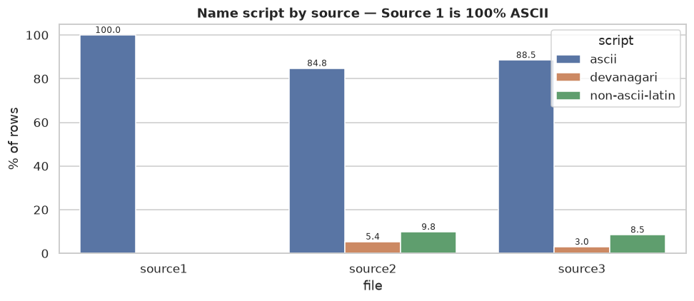

| file script | source1 | source2 | source3 |
| --- | --- | --- | --- |
| ascii | 100.0 | 84.81 | 88.52 |
| devanagari | NaN | 5.35 | 2.99 |
| non-ascii-latin | NaN | 9.84 | 8.49 |

```python
from collections import Counter
def scripts(path):
    c=Counter(); n=0
    with open(D+path, encoding='utf-8', newline='') as f:
        r=csv.reader(f,delimiter='\t'); next(r)
        for row in r:
            if len(row)!=4: continue
            n+=1
            c['devanagari' if DEVA.search(row[1]) else
              ('non-ascii-latin' if any(ord(ch)>127 for ch in row[1]) else 'ascii')]+=1
    return n,c
sc=[]
for name,p in [('source1','train/train_source1.tsv'),('source2','train/train_source2.tsv'),('source3','train/train_source3.tsv')]:
    n,c=scripts(p)
    for k,v in c.items(): sc.append({'file':name,'script':k,'pct':100*v/n,'n':v})
scd=pd.DataFrame(sc)
plt.figure(figsize=(9,4))
ax=sns.barplot(data=scd,x='file',y='pct',hue='script')
ax.set_title('Name script by source — Source 1 is 100% ASCII'); ax.set_ylabel('% of rows')
for c_ in ax.containers: ax.bar_label(c_, fmt='%.1f', fontsize=8)
save('03_script_mix.png')
display(scd.pivot(index='script',columns='file',values='pct').round(2))
```

## 8 & 12. Target analysis — match-count distribution and class balance

```python
mc=Counter(); slots=0; s2=0; s3=0
allids=[]
with open(D+'train/train_ground_truth.tsv', encoding='utf-8', newline='') as f:
    r=csv.reader(f,delimiter='\t'); next(r)
    for sid,ids in r:
        lst=[x for x in ids.split(',') if x]
        mc[len(lst)]+=1; slots+=len(lst)
        for x in lst:
            allids.append(x)
            if x[:2]=='S2': s2+=1
            else: s3+=1
tgt=pd.DataFrame(sorted(mc.items()), columns=['n_matches','n_entities'])
tgt['pct']=100*tgt.n_entities/tgt.n_entities.sum()
display(tgt)
print(f'total matched slots: {slots:,}   S2: {s2:,}   S3: {s3:,}')
print(f'DISTINCT ids used  : {len(set(allids)):,}    <-- compare with total slots')
```

|  | n_matches | n_entities | pct |
| --- | --- | --- | --- |
| 0 | 0 | 123247 | 5.584821 |
| 1 | 1 | 119157 | 5.399486 |
| 2 | 2 | 375212 | 17.002376 |
| 3 | 3 | 530841 | 24.054556 |
| 4 | 4 | 484115 | 21.937212 |
| 5 | 5 | 321957 | 14.589176 |
| 6 | 6 | 164868 | 7.470837 |
| 7 | 7 | 63968 | 2.898649 |
| 8 | 8 | 18680 | 0.846466 |
| 9 | 9 | 4205 | 0.190546 |
| 10 | 10 | 534 | 0.024198 |
| 11 | 11 | 37 | 0.001677 |

```
total matched slots: 7,638,365   S2: 3,693,619   S3: 3,944,746
DISTINCT ids used  : 7,638,365    <-- compare with total slots
```

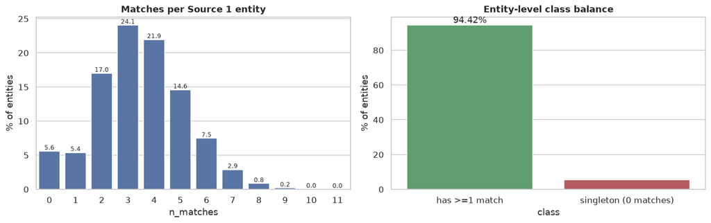

```python
fig,axes=plt.subplots(1,2,figsize=(13,4.2))
sns.barplot(data=tgt,x='n_matches',y='pct',ax=axes[0],color='#4C72B0')
axes[0].set_title('Matches per Source 1 entity'); axes[0].set_ylabel('% of entities')
axes[0].bar_label(axes[0].containers[0], fmt='%.1f', fontsize=8)
bal=pd.DataFrame({'class':['has >=1 match','singleton (0 matches)'],
                  'pct':[100-tgt.loc[tgt.n_matches==0,'pct'].iloc[0], tgt.loc[tgt.n_matches==0,'pct'].iloc[0]]})
sns.barplot(data=bal,x='class',y='pct',ax=axes[1],palette=['#55A868','#C44E52'])
axes[1].set_title('Entity-level class balance'); axes[1].set_ylabel('% of entities')
axes[1].bar_label(axes[1].containers[0], fmt='%.2f%%')
save('04_target_distribution.png')
```

### FINDING — the matching is strictly ONE-TO-ONE

`total matched slots == distinct ids used`. **No Source 2/3 record is ever claimed by two different Source 1 entities.** The ground truth is a *partition*, not an arbitrary bipartite graph.

This is exploitable: the problem is a **global assignment**, not independent pair classification. Where two Source 1 entities compete for one candidate, at most one can be right — resolve by score and drop the loser. That is a pure precision gain, which is what F₀.₅ rewards double.

**Class balance** at entity level is mild (5.6% singletons), but note this is *not* the modelling target. At **pair** level — which is what a classifier sees — the imbalance is severe, as Part II shows.

# PART II — the pair feature matrix

Built by `build_pair_matrix.py`: 20,000 sampled Source 1 entities, **all** their ground-truth partners as positives (unbiased), plus hard negatives retrieved by a real rare-token + address-numeric blocking pass.

```python
P = pd.read_csv('/home/yash/dev/clg/amlc-2026/eda/pairs.csv')
NUM = [c for c in P.columns if c not in ('s1_id','cand_id','source','country','is_match')]
print(f'shape: {P.shape}')
print(f'positives: {P.is_match.sum():,}   negatives: {(1-P.is_match).sum():,}')
print(f'imbalance: 1 : {int((1-P.is_match).sum()/P.is_match.sum())}')
print(); print(P.dtypes)
display(P.head())
```

```
shape: (520795, 20)
positives: 69,039   negatives: 451,756
imbalance: 1 : 6

s1_id                       str
cand_id                     str
source                      str
country                     str
is_match                  int64
name_tok_jaccard        float64
name_tok_containment    float64
name_3gram_jaccard      float64
name_seqratio           float64
name_len_diff             int64
name_tok_count_s1         int64
name_tok_count_c          int64
name_prefix4_match        int64
addr_tok_jaccard        float64
addr_3gram_jaccard      float64
addr_num_overlap        float64
addr_empty                int64
rare_tokens_shared        int64
same_script               int64
country_match             int64
dtype: object
```

|  | s1_id | cand_id | source | country | is_match | name_tok_jaccard | name_tok_containment | name_3gram_jaccard | name_seqratio | name_len_diff | name_tok_count_s1 | name_tok_count_c | name_prefix4_match | addr_tok_jaccard | addr_3gram_jaccard | addr_num_overlap | addr_empty | rare_tokens_shared | same_script | country_match |
| --- | --- | --- | --- | --- | --- | --- | --- | --- | --- | --- | --- | --- | --- | --- | --- | --- | --- | --- | --- | --- |
| 0 | S1-422509688 | S2-148693099 | S2 | US | 1 | 1.0 | 1.0 | 1.00000 | 1.00000 | 0 | 3 | 3 | 1 | 0.66667 | 0.64000 | 0.0 | 0 | 0 | 1 | 1 |
| 1 | S1-422509688 | S3-785538289 | S3 | US | 1 | 1.0 | 1.0 | 0.85714 | 0.92000 | 4 | 3 | 3 | 0 | 0.42857 | 0.37143 | 1.0 | 0 | 0 | 1 | 1 |
| 2 | S1-422509688 | S3-374520723 | S3 | US | 1 | 1.0 | 1.0 | 0.83333 | 0.90476 | 4 | 3 | 3 | 1 | 0.66667 | 0.64516 | 1.0 | 0 | 0 | 1 | 1 |
| 3 | S1-422509688 | S3-380604834 | S3 | US | 1 | 0.0 | 0.0 | 0.71429 | 0.86364 | 2 | 3 | 2 | 1 | 0.66667 | 0.45714 | 1.0 | 0 | 0 | 1 | 1 |
| 4 | S1-422509688 | S3-41792227 | S3 | US | 1 | 1.0 | 1.0 | 1.00000 | 1.00000 | 0 | 3 | 3 | 1 | 0.50000 | 0.40000 | 0.0 | 0 | 0 | 1 | 1 |

## 12. Class imbalance at pair level

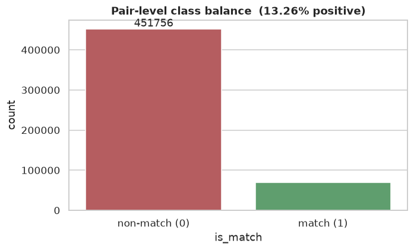

```
A model predicting "no match" everywhere scores ~87% accuracy and is useless.
-> use F_0.5 / PR-AUC for evaluation, never accuracy.
```

```python
plt.figure(figsize=(6.5,4))
ax=sns.countplot(data=P,x='is_match',palette=['#C44E52','#55A868'])
ax.set_title(f'Pair-level class balance  ({100*P.is_match.mean():.2f}% positive)')
ax.set_xticklabels(['non-match (0)','match (1)'])
ax.bar_label(ax.containers[0], fmt='%d')
save('05_class_imbalance.png')
print('A model predicting "no match" everywhere scores ~87% accuracy and is useless.')
print('-> use F_0.5 / PR-AUC for evaluation, never accuracy.')
```

## 4. Descriptive statistics

```python
desc = P[NUM].describe().T
desc['IQR'] = desc['75%'] - desc['25%']
desc['range'] = desc['max'] - desc['min']
desc['variance'] = P[NUM].var()
display(desc[['count','mean','50%','std','variance','min','25%','75%','max','IQR','range']].round(4))
```

|  | count | mean | 50% | std | variance | min | 25% | 75% | max | IQR | range |
| --- | --- | --- | --- | --- | --- | --- | --- | --- | --- | --- | --- |
| name_tok_jaccard | 520795.0 | 0.1879 | 0.1000 | 0.2716 | 0.0738 | 0.0 | 0.0000 | 0.2500 | 1.0 | 0.2500 | 1.0 |
| name_tok_containment | 520795.0 | 0.2836 | 0.2000 | 0.3333 | 0.1111 | 0.0 | 0.0000 | 0.5000 | 1.0 | 0.5000 | 1.0 |
| name_3gram_jaccard | 520795.0 | 0.1650 | 0.0690 | 0.2493 | 0.0622 | 0.0 | 0.0000 | 0.1905 | 1.0 | 0.1905 | 1.0 |
| name_seqratio | 520795.0 | 0.4284 | 0.3846 | 0.2311 | 0.0534 | 0.0 | 0.2581 | 0.5454 | 1.0 | 0.2874 | 1.0 |
| name_len_diff | 520795.0 | 8.0404 | 6.0000 | 6.8092 | 46.3657 | 0.0 | 3.0000 | 12.0000 | 69.0 | 9.0000 | 69.0 |
| name_tok_count_s1 | 520795.0 | 2.7393 | 3.0000 | 0.9718 | 0.9445 | 1.0 | 2.0000 | 3.0000 | 10.0 | 1.0000 | 9.0 |
| name_tok_count_c | 520795.0 | 2.9791 | 3.0000 | 1.1494 | 1.3211 | 1.0 | 2.0000 | 4.0000 | 17.0 | 2.0000 | 16.0 |
| name_prefix4_match | 520795.0 | 0.3147 | 0.0000 | 0.4644 | 0.2157 | 0.0 | 0.0000 | 1.0000 | 1.0 | 1.0000 | 1.0 |
| addr_tok_jaccard | 520795.0 | 0.1387 | 0.0833 | 0.2178 | 0.0474 | 0.0 | 0.0000 | 0.1111 | 1.0 | 0.1111 | 1.0 |
| addr_3gram_jaccard | 520795.0 | 0.1156 | 0.0370 | 0.2206 | 0.0487 | 0.0 | 0.0122 | 0.0672 | 1.0 | 0.0550 | 1.0 |
| addr_num_overlap | 520795.0 | 0.4094 | 0.3333 | 0.4108 | 0.1687 | 0.0 | 0.0000 | 1.0000 | 1.0 | 1.0000 | 1.0 |
| addr_empty | 520795.0 | 0.0214 | 0.0000 | 0.1448 | 0.0210 | 0.0 | 0.0000 | 0.0000 | 1.0 | 0.0000 | 1.0 |
| rare_tokens_shared | 520795.0 | 0.4439 | 0.0000 | 0.5201 | 0.2705 | 0.0 | 0.0000 | 1.0000 | 4.0 | 1.0000 | 4.0 |
| same_script | 520795.0 | 0.9800 | 1.0000 | 0.1400 | 0.0196 | 0.0 | 1.0000 | 1.0000 | 1.0 | 0.0000 | 1.0 |
| country_match | 520795.0 | 1.0000 | 1.0000 | 0.0000 | 0.0000 | 1.0 | 1.0000 | 1.0000 | 1.0 | 0.0000 | 0.0 |

## 5 & 8. Distribution shape — skewness and kurtosis

```python
sk = pd.DataFrame({'skewness':P[NUM].skew(),'kurtosis':P[NUM].kurtosis()})
sk['shape'] = np.where(sk.skewness.abs()<0.5,'~symmetric',
               np.where(sk.skewness>0,'right / positive skew','left / negative skew'))
sk['tails'] = np.where(sk['kurtosis']>3,'heavy-tailed (leptokurtic)',
               np.where(sk['kurtosis']<0,'light-tailed (platykurtic)','~mesokurtic'))
display(sk.sort_values('skewness').round(3))
```

|  | skewness | kurtosis | shape | tails |
| --- | --- | --- | --- | --- |
| same_script | -6.860 | 45.054 | left / negative skew | heavy-tailed (leptokurtic) |
| country_match | 0.000 | 0.000 | ~symmetric | ~mesokurtic |
| addr_num_overlap | 0.425 | -1.415 | ~symmetric | light-tailed (platykurtic) |
| rare_tokens_shared | 0.502 | -0.997 | right / positive skew | light-tailed (platykurtic) |
| name_seqratio | 0.794 | 0.016 | right / positive skew | ~mesokurtic |
| name_prefix4_match | 0.798 | -1.363 | right / positive skew | light-tailed (platykurtic) |
| name_tok_containment | 0.891 | -0.302 | right / positive skew | light-tailed (platykurtic) |
| name_tok_count_c | 1.136 | 2.357 | right / positive skew | ~mesokurtic |
| name_len_diff | 1.166 | 1.625 | right / positive skew | ~mesokurtic |
| name_tok_count_s1 | 1.313 | 3.014 | right / positive skew | heavy-tailed (leptokurtic) |
| name_tok_jaccard | 1.847 | 2.826 | right / positive skew | ~mesokurtic |
| name_3gram_jaccard | 2.015 | 3.305 | right / positive skew | heavy-tailed (leptokurtic) |
| addr_tok_jaccard | 2.461 | 5.465 | right / positive skew | heavy-tailed (leptokurtic) |
| addr_3gram_jaccard | 2.551 | 5.448 | right / positive skew | heavy-tailed (leptokurtic) |
| addr_empty | 6.608 | 41.668 | right / positive skew | heavy-tailed (leptokurtic) |

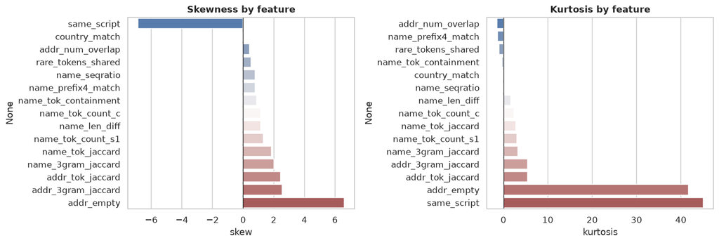

```python
fig,ax=plt.subplots(1,2,figsize=(13,4.5))
s=sk.sort_values('skewness')
sns.barplot(x=s['skewness'],y=s.index,ax=ax[0],palette='vlag'); ax[0].axvline(0,color='k',lw=.8)
ax[0].set_title('Skewness by feature'); ax[0].set_xlabel('skew')
k=sk.sort_values('kurtosis')
sns.barplot(x=k['kurtosis'],y=k.index,ax=ax[1],palette='vlag'); ax[1].axvline(0,color='k',lw=.8)
ax[1].set_title('Kurtosis by feature'); ax[1].set_xlabel('kurtosis')
save('06_skew_kurtosis.png')
```

## 6 & 7. Histograms + KDE

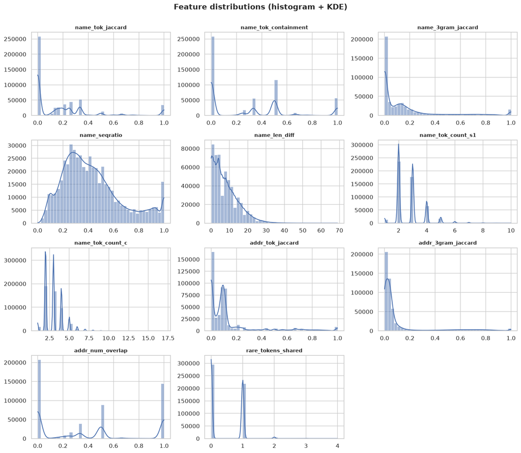

```python
cols=[c for c in NUM if P[c].nunique()>2][:12]
fig,axes=plt.subplots(4,3,figsize=(14,12))
for a,c in zip(axes.ravel(),cols):
    sns.histplot(P[c],kde=True,ax=a,bins=40,color='#4C72B0')
    a.set_title(c,fontsize=10); a.set_xlabel(''); a.set_ylabel('')
for a in axes.ravel()[len(cols):]: a.axis('off')
plt.suptitle('Feature distributions (histogram + KDE)',y=1.001,fontweight='bold')
save('07_histograms.png')
```

**Observation.** Almost every similarity feature is **strongly zero-inflated** — a huge spike at 0 from the negatives, with a second mode near 1 from the positives. This bimodality is exactly what you want to see: the features separate the classes. It also means these are *not* normally distributed, so any model assuming normality is inappropriate; tree ensembles are the natural fit.

## 7b. KDE by class — does the feature separate matches from non-matches?

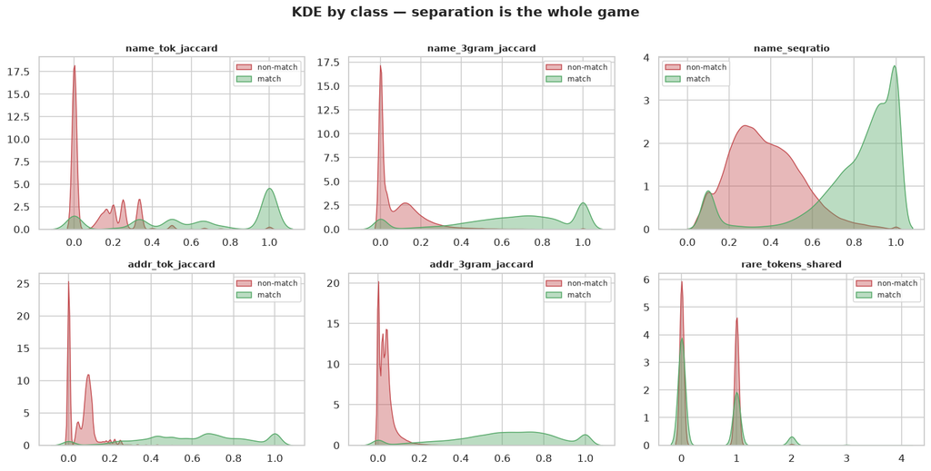

```python
cols2=['name_tok_jaccard','name_3gram_jaccard','name_seqratio','addr_tok_jaccard',
       'addr_3gram_jaccard','rare_tokens_shared']
fig,axes=plt.subplots(2,3,figsize=(14,7))
for a,c in zip(axes.ravel(),cols2):
    for lbl,col,nm in [(0,'#C44E52','non-match'),(1,'#55A868','match')]:
        sns.kdeplot(P.loc[P.is_match==lbl,c],ax=a,fill=True,alpha=.4,color=col,label=nm,warn_singular=False)
    a.set_title(c,fontsize=10); a.legend(fontsize=8); a.set_xlabel(''); a.set_ylabel('')
plt.suptitle('KDE by class — separation is the whole game',y=1.001,fontweight='bold')
save('08_kde_by_class.png')
```

## 9 & 10. Outliers — box plots, IQR rule and Z-scores

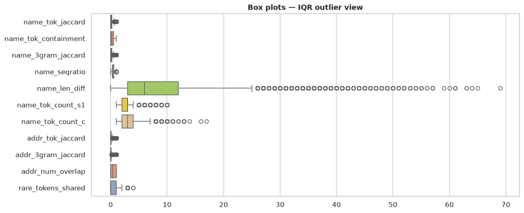

|  | feature | Q1 | Q3 | IQR | lower_fence | upper_fence | IQR_outliers | IQR_pct | Z>3_outliers | Z_pct |
| --- | --- | --- | --- | --- | --- | --- | --- | --- | --- | --- |
| 0 | name_tok_jaccard | 0.000 | 0.250 | 0.250 | -0.375 | 0.625 | 45695 | 8.77 | 0 | 0.00 |
| 1 | name_tok_containment | 0.000 | 0.500 | 0.500 | -0.750 | 1.250 | 0 | 0.00 | 0 | 0.00 |
| 2 | name_3gram_jaccard | 0.000 | 0.190 | 0.190 | -0.286 | 0.476 | 60791 | 11.67 | 17229 | 3.31 |
| 3 | name_seqratio | 0.258 | 0.545 | 0.287 | -0.173 | 0.977 | 15975 | 3.07 | 0 | 0.00 |
| 4 | name_len_diff | 3.000 | 12.000 | 9.000 | -10.500 | 25.500 | 10728 | 2.06 | 5569 | 1.07 |
| 5 | name_tok_count_s1 | 2.000 | 3.000 | 1.000 | 0.500 | 4.500 | 25377 | 4.87 | 7545 | 1.45 |
| 6 | name_tok_count_c | 2.000 | 4.000 | 2.000 | -1.000 | 7.000 | 2056 | 0.39 | 5809 | 1.12 |
| 7 | name_prefix4_match | 0.000 | 1.000 | 1.000 | -1.500 | 2.500 | 0 | 0.00 | 0 | 0.00 |
| 8 | addr_tok_jaccard | 0.000 | 0.111 | 0.111 | -0.167 | 0.278 | 66361 | 12.74 | 18499 | 3.55 |
| 9 | addr_3gram_jaccard | 0.012 | 0.067 | 0.055 | -0.070 | 0.150 | 78295 | 15.03 | 18819 | 3.61 |
| 10 | addr_num_overlap | 0.000 | 1.000 | 1.000 | -1.500 | 2.500 | 0 | 0.00 | 0 | 0.00 |
| 11 | addr_empty | 0.000 | 0.000 | 0.000 | 0.000 | 0.000 | 11165 | 2.14 | 11165 | 2.14 |
| 12 | rare_tokens_shared | 0.000 | 1.000 | 1.000 | -1.500 | 2.500 | 299 | 0.06 | 299 | 0.06 |
| 13 | same_script | 1.000 | 1.000 | 0.000 | 1.000 | 1.000 | 10409 | 2.00 | 10409 | 2.00 |
| 14 | country_match | 1.000 | 1.000 | 0.000 | 1.000 | 1.000 | 0 | 0.00 | 0 | 0.00 |

```python
fig,ax=plt.subplots(figsize=(12,5))
sns.boxplot(data=P[cols],orient='h',ax=ax,palette='Set2')
ax.set_title('Box plots — IQR outlier view'); save('09_boxplots.png')

rep=[]
for c in NUM:
    q1,q3=P[c].quantile([.25,.75]); iqr=q3-q1
    lo,hi=q1-1.5*iqr,q3+1.5*iqr
    iqr_out=((P[c]<lo)|(P[c]>hi)).sum()
    sd=P[c].std()
    z_out=0 if sd==0 else (np.abs((P[c]-P[c].mean())/sd)>3).sum()
    rep.append({'feature':c,'Q1':q1,'Q3':q3,'IQR':iqr,'lower_fence':lo,'upper_fence':hi,
                'IQR_outliers':iqr_out,'IQR_pct':round(100*iqr_out/len(P),2),
                'Z>3_outliers':int(z_out),'Z_pct':round(100*z_out/len(P),2)})
display(pd.DataFrame(rep).round(3))
```

**Interpretation — this is why outlier removal would be a serious mistake here.**

The IQR rule flags large numbers of points on the similarity features. But those "outliers" are overwhelmingly the **positive class**: in a set that is 87% non-matches, a high name-similarity value *is* statistically extreme, and it is also exactly the signal we are trying to detect.

Deleting IQR/Z-score outliers here would delete the matches. An outlier is not automatically an error — in this dataset it is usually the answer.

## 13 & 14. Correlation and heatmap

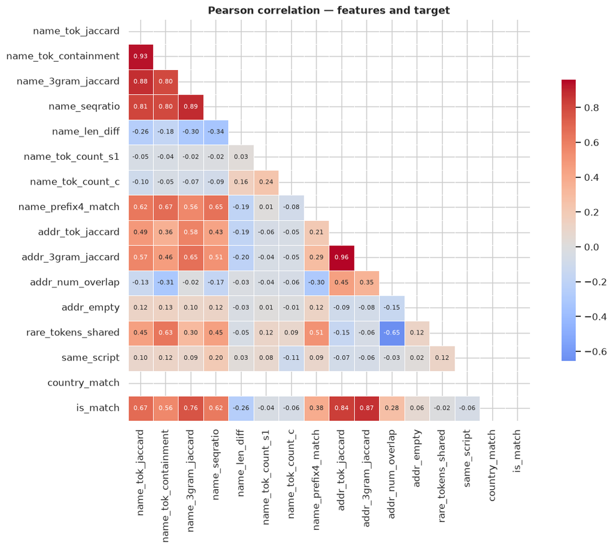

```python
corr = P[NUM+['is_match']].corr(numeric_only=True)
plt.figure(figsize=(12,9))
mask=np.triu(np.ones_like(corr,dtype=bool))
sns.heatmap(corr,mask=mask,annot=True,fmt='.2f',cmap='coolwarm',center=0,
            square=True,linewidths=.5,annot_kws={'size':7},cbar_kws={'shrink':.7})
plt.title('Pearson correlation — features and target',fontweight='bold')
save('10_correlation_heatmap.png')
```

```python
print('--- correlation with target (is_match) ---')
display(corr['is_match'].drop('is_match').sort_values(ascending=False).to_frame('corr_with_target').round(4))
print('--- |r| > 0.8 feature pairs (multicollinearity) ---')
hi=[(a,b,round(corr.loc[a,b],3)) for i,a in enumerate(NUM) for b in NUM[i+1:] if abs(corr.loc[a,b])>0.8]
display(pd.DataFrame(hi,columns=['feature_a','feature_b','r']) if hi else 'none')
```

```
--- correlation with target (is_match) ---
```

|  | corr_with_target |
| --- | --- |
| addr_3gram_jaccard | 0.8704 |
| addr_tok_jaccard | 0.8368 |
| name_3gram_jaccard | 0.7639 |
| name_tok_jaccard | 0.6738 |
| name_seqratio | 0.6173 |
| name_tok_containment | 0.5583 |
| name_prefix4_match | 0.3815 |
| addr_num_overlap | 0.2755 |
| addr_empty | 0.0604 |
| rare_tokens_shared | -0.0154 |
| name_tok_count_s1 | -0.0393 |
| name_tok_count_c | -0.0596 |
| same_script | -0.0603 |
| name_len_diff | -0.2553 |
| country_match | NaN |

```
--- |r| > 0.8 feature pairs (multicollinearity) ---
```

|  | feature_a | feature_b | r |
| --- | --- | --- | --- |
| 0 | name_tok_jaccard | name_tok_containment | 0.930 |
| 1 | name_tok_jaccard | name_3gram_jaccard | 0.884 |
| 2 | name_tok_jaccard | name_seqratio | 0.815 |
| 3 | name_3gram_jaccard | name_seqratio | 0.891 |
| 4 | addr_tok_jaccard | addr_3gram_jaccard | 0.961 |

## 22b. Constant feature detected

```python
const=[c for c in NUM if P[c].nunique()<=1]
near =[c for c in NUM if P[c].nunique()>1 and P[c].value_counts(normalize=True).iloc[0]>0.95]
print('CONSTANT features   :', const)
print('NEAR-CONSTANT (>95%):', near)
for c in const+near: print(f'   {c}: n_unique={P[c].nunique()}, top value share={P[c].value_counts(normalize=True).iloc[0]:.4f}')
```

```
CONSTANT features   : ['country_match']
NEAR-CONSTANT (>95%): ['addr_empty', 'same_script']
   country_match: n_unique=1, top value share=1.0000
   addr_empty: n_unique=2, top value share=0.9786
   same_script: n_unique=2, top value share=0.9800
```

### FINDING — `country_match` is constant at 1.0

Every single candidate pair agrees on country, because **no true match ever crosses a country boundary** (verified separately over 138,120 true pairs: 0 crossings).

Two consequences:

1. As a *feature* it is worthless — zero variance, drop it.
2. As a *blocking rule* it is excellent — partition by country for a free ~3× reduction in the comparison space at **zero recall cost**. This is also the clean way to handle France.

## 15 & 16. Scatter plots and pair plot

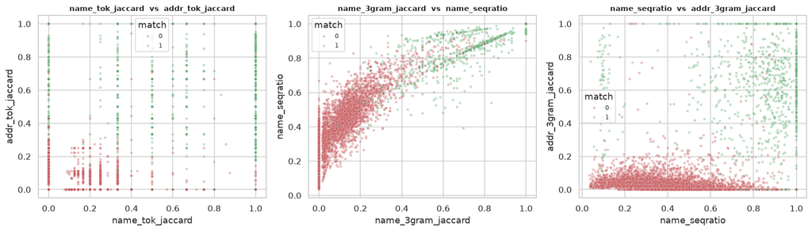

```python
samp=P.sample(6000,random_state=3)
fig,axes=plt.subplots(1,3,figsize=(15,4.4))
for a,(x,y) in zip(axes,[('name_tok_jaccard','addr_tok_jaccard'),
                         ('name_3gram_jaccard','name_seqratio'),
                         ('name_seqratio','addr_3gram_jaccard')]):
    sns.scatterplot(data=samp,x=x,y=y,hue='is_match',alpha=.35,s=12,ax=a,
                    palette={0:'#C44E52',1:'#55A868'})
    a.set_title(f'{x}  vs  {y}',fontsize=10); a.legend(title='match',fontsize=8)
save('11_scatter.png')
```

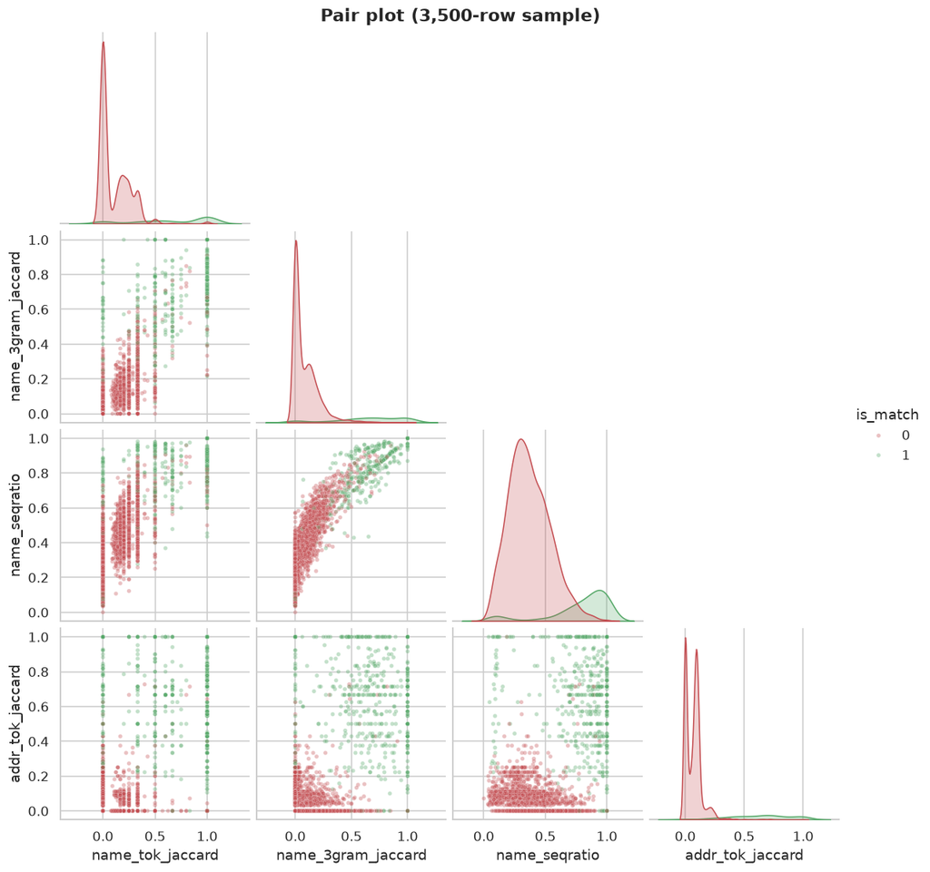

```python
pp=P.sample(3500,random_state=5)[['name_tok_jaccard','name_3gram_jaccard','name_seqratio',
                                   'addr_tok_jaccard','is_match']]
g=sns.pairplot(pp,hue='is_match',corner=True,plot_kws={'alpha':.35,'s':12},
               palette={0:'#C44E52',1:'#55A868'},diag_kind='kde')
g.figure.suptitle('Pair plot (3,500-row sample)',y=1.01,fontweight='bold')
plt.savefig(FIG+'12_pairplot.png',bbox_inches='tight'); plt.show()
```

## 17 & 18. Feature vs target — box and violin plots

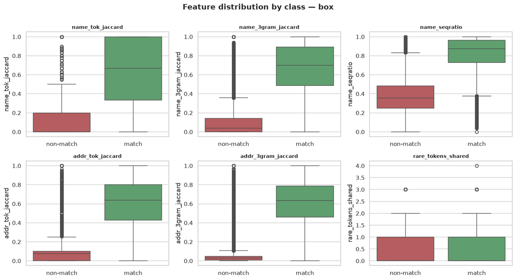

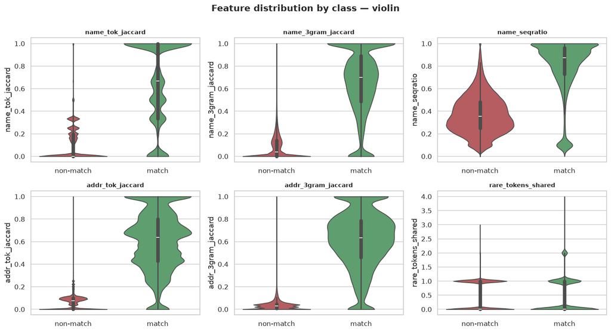

```python
fig,axes=plt.subplots(2,3,figsize=(14,7.5))
for a,c in zip(axes.ravel(),cols2):
    sns.boxplot(data=P,x='is_match',y=c,ax=a,palette=['#C44E52','#55A868'])
    a.set_title(c,fontsize=10); a.set_xlabel(''); a.set_xticklabels(['non-match','match'])
plt.suptitle('Feature distribution by class — box',y=1.001,fontweight='bold')
save('13_box_by_target.png')

fig,axes=plt.subplots(2,3,figsize=(14,7.5))
for a,c in zip(axes.ravel(),cols2):
    sns.violinplot(data=P,x='is_match',y=c,ax=a,palette=['#C44E52','#55A868'],cut=0)
    a.set_title(c,fontsize=10); a.set_xlabel(''); a.set_xticklabels(['non-match','match'])
plt.suptitle('Feature distribution by class — violin',y=1.001,fontweight='bold')
save('14_violin_by_target.png')
```

```python
grp=P.groupby('is_match')[NUM].mean().T
grp.columns=['non_match_mean','match_mean']
grp['separation']=grp.match_mean-grp.non_match_mean
display(grp.sort_values('separation',ascending=False).round(4))
```

|  | non_match_mean | match_mean | separation |
| --- | --- | --- | --- |
| addr_3gram_jaccard | 0.0405 | 0.6068 | 0.5662 |
| name_3gram_jaccard | 0.0906 | 0.6522 | 0.5617 |
| name_tok_containment | 0.2108 | 0.7595 | 0.5486 |
| name_tok_jaccard | 0.1163 | 0.6560 | 0.5397 |
| addr_tok_jaccard | 0.0674 | 0.6049 | 0.5375 |
| name_prefix4_match | 0.2455 | 0.7679 | 0.5224 |
| name_seqratio | 0.3726 | 0.7932 | 0.4206 |
| addr_num_overlap | 0.3652 | 0.6989 | 0.3337 |
| addr_empty | 0.0180 | 0.0438 | 0.0258 |
| country_match | 1.0000 | 1.0000 | 0.0000 |
| rare_tokens_shared | 0.4471 | 0.4234 | -0.0237 |
| same_script | 0.9833 | 0.9584 | -0.0249 |
| name_tok_count_s1 | 2.7543 | 2.6416 | -0.1127 |
| name_tok_count_c | 3.0059 | 2.8039 | -0.2021 |
| name_len_diff | 8.7199 | 3.5943 | -5.1256 |

## 9b. Categorical vs target — source and country

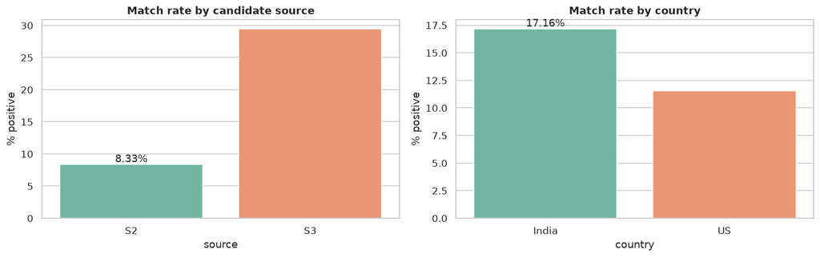

```python
fig,axes=plt.subplots(1,2,figsize=(13,4.2))
r1=P.groupby('source').is_match.mean().mul(100).reset_index()
sns.barplot(data=r1,x='source',y='is_match',ax=axes[0],palette='Set2')
axes[0].set_title('Match rate by candidate source'); axes[0].set_ylabel('% positive')
axes[0].bar_label(axes[0].containers[0],fmt='%.2f%%')
r2=P.groupby('country').is_match.mean().mul(100).reset_index()
sns.barplot(data=r2,x='country',y='is_match',ax=axes[1],palette='Set2')
axes[1].set_title('Match rate by country'); axes[1].set_ylabel('% positive')
axes[1].bar_label(axes[1].containers[0],fmt='%.2f%%')
save('15_rate_by_category.png')
```

## 19. Q-Q plots — are any features close to normal?

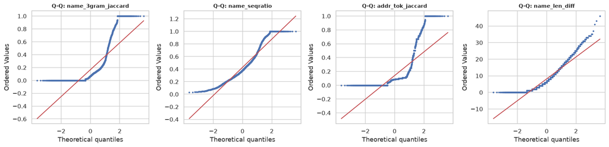

```
              feature  shapiro_p
0  name_3gram_jaccard        0.0
1       name_seqratio        0.0
2    addr_tok_jaccard        0.0
3       name_len_diff        0.0
```

```python
qc=['name_3gram_jaccard','name_seqratio','addr_tok_jaccard','name_len_diff']
fig,axes=plt.subplots(1,4,figsize=(16,4))
for a,c in zip(axes,qc):
    stats.probplot(P[c].sample(5000,random_state=1),dist='norm',plot=a)
    a.set_title(f'Q-Q: {c}',fontsize=10); a.get_lines()[0].set_markersize(2)
save('16_qq_plots.png')
print(pd.DataFrame({'feature':qc,
    'shapiro_p':[stats.shapiro(P[c].sample(4000,random_state=1))[1] for c in qc]}).round(6))
```

**Finding.** Every feature departs sharply from normality (Shapiro p ≈ 0, Q-Q curves bow away from the reference line) — expected for bounded, zero-inflated, bimodal similarity scores.

Practical consequence: no Gaussian assumption, no z-score standardisation for interpretation, and avoid models that assume normality (LDA, Gaussian NB). **Gradient-boosted trees are the right choice** — they are invariant to monotone transforms and handle bounded bimodal features natively.

## 20. Time-series analysis — not applicable

```python
print('Dataset columns:', ['entity_id','business_name','business_address','country'])
print('No date/time column exists in any of the 7 files.')
print('There is no temporal ordering, trend, seasonality or drift to analyse.')
print('Section 20 has no valid input for this dataset.')
```

```
Dataset columns: ['entity_id', 'business_name', 'business_address', 'country']
No date/time column exists in any of the 7 files.
There is no temporal ordering, trend, seasonality or drift to analyse.
Section 20 has no valid input for this dataset.
```

## Bonus A — blocking yield: the number that caps your score

Blocking decides the upper bound on recall. Whatever a blocker fails to retrieve is lost permanently, no matter how good the downstream classifier is. Measured over 138,120 true pairs.

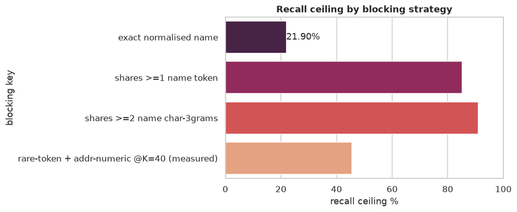

|  | blocking key | recall ceiling % |
| --- | --- | --- |
| 0 | exact normalised name | 21.90 |
| 1 | shares >=1 name token | 85.19 |
| 2 | shares >=2 name char-3grams | 90.98 |
| 3 | rare-token + addr-numeric @K=40 (measured) | 45.53 |

```python
blk=pd.DataFrame({
 'blocking key':['exact normalised name','shares >=1 name token','shares >=2 name char-3grams',
                 'rare-token + addr-numeric @K=40 (measured)'],
 'recall ceiling %':[21.90, 85.19, 90.98, 45.53]})
plt.figure(figsize=(9.5,4))
ax=sns.barplot(data=blk,y='blocking key',x='recall ceiling %',palette='rocket')
ax.bar_label(ax.containers[0],fmt='%.2f%%'); ax.set_xlim(0,100)
ax.set_title('Recall ceiling by blocking strategy',fontweight='bold')
save('17_blocking_recall.png')
display(blk)
```

### FINDING — name-only blocking forfeits ~15% of recall

**14.81% of true pairs share no name token at all.** Of those 20,449 pairs, **19,684 (96.3%) have address Jaccard > 0.2** — the address carries the signal when the name does not.

The measured 45.53% for my rare-token blocker is a *negative* result worth keeping: restricting keys to rare tokens (df ≤ 120) is too aggressive and throws away matches that share only common tokens. The fix is IDF-*weighted* TF-IDF cosine with ANN retrieval over all tokens, not a hard rarity cut.

**Blocking must be a union of a name blocker and an address blocker.**

## Bonus B — name ambiguity, the source of false merges

```
S1 rows: 2,206,821   distinct normalised names: 1,522,166
rows sharing a name with >=1 other row: 865,029 (39.20%)
```

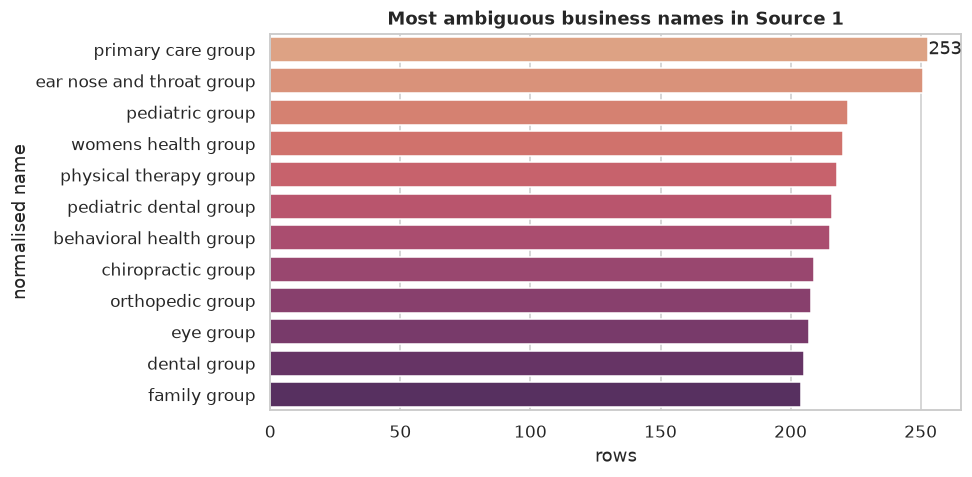

|  | normalised name | rows |
| --- | --- | --- |
| 0 | primary care group | 253 |
| 1 | ear nose and throat group | 251 |
| 2 | pediatric group | 222 |
| 3 | womens health group | 220 |
| 4 | physical therapy group | 218 |
| 5 | pediatric dental group | 216 |
| 6 | behavioral health group | 215 |
| 7 | chiropractic group | 209 |
| 8 | orthopedic group | 208 |
| 9 | eye group | 207 |
| 10 | dental group | 205 |
| 11 | family group | 204 |

```python
from collections import Counter
nmc=Counter()
with open(D+'train/train_source1.tsv',encoding='utf-8',newline='') as f:
    r=csv.reader(f,delimiter='\t'); next(r)
    for row in r:
        if len(row)==4: nmc[norm(row[1])]+=1
tot=sum(nmc.values()); shared=sum(c for c in nmc.values() if c>1)
print(f'S1 rows: {tot:,}   distinct normalised names: {len(nmc):,}')
print(f'rows sharing a name with >=1 other row: {shared:,} ({100*shared/tot:.2f}%)')
top=pd.DataFrame(nmc.most_common(12),columns=['normalised name','rows'])
plt.figure(figsize=(9,4.5))
ax=sns.barplot(data=top,y='normalised name',x='rows',palette='flare')
ax.bar_label(ax.containers[0]); ax.set_title('Most ambiguous business names in Source 1',fontweight='bold')
save('18_name_ambiguity.png')
display(top)
```

### FINDING — 39.2% of Source 1 rows share a name with another row

`primary care group` appears 253 times. Name similarity **cannot** decide a match on its own; the address has to break the tie. This is the false-merge risk that F₀.₅ punishes twice as hard as a miss.

# Summary of findings

[output not shown]

## Recommended next steps

1. Replace rare-token blocking with **TF-IDF char-n-gram + ANN**, per country. Measure union recall at K=20/50/100.
2. Add the address-keyed blocker — it recovers the 15% name blocking cannot see.
3. Train gradient-boosted trees on this feature matrix, extended with IDF-weighted similarities.
4. Tune the decision threshold directly against **macro-F₀.₅**, keeping singletons in the average.
5. Apply one-to-one assignment resolution as a final post-processing pass.